Lake Name: Orange Lake

Lake acreage: 411.8

County: ORANGE

PWLID: 1301-0008

Waterbody Classification: B

Coordinates: 41.548801,-74.103699

Is this waterbody a public water supply: No

Are there DOH desingated beaches on this waterbody: No

Open Water Indicators

2018 Sampling Results

Seasonal Change

Longterm Avg

Season Avg

Season Diff From Avg

05-29

06-11

06-25

07-09

08-21

09-17

08-01

10-01

Clarity (m)

1.2

0.9

0.7

0.7

0.8

0.9

0.4

0.8

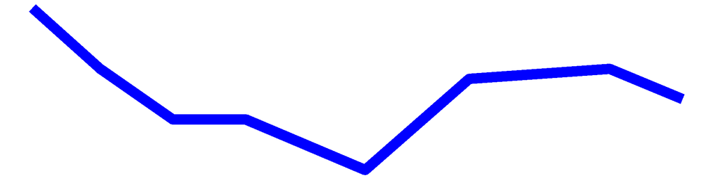

1.01821782

0.8

no.png

Surface TP (mg/L)

0.03

0.05

0.044

0.04

0.041

0.063

0.04

0.035

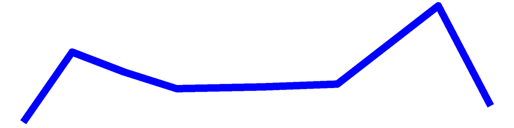

0.04599628

0.043

no.png

Surface TDP (mg/L)

0.009

0.005

0.011

0.009

0.027

0.007

0.006

0.018

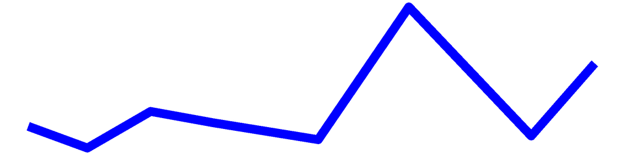

0.012

TN (mg/L)

0.919

0.724

0.875

1.095

1.181

1.53

1.867

0.959

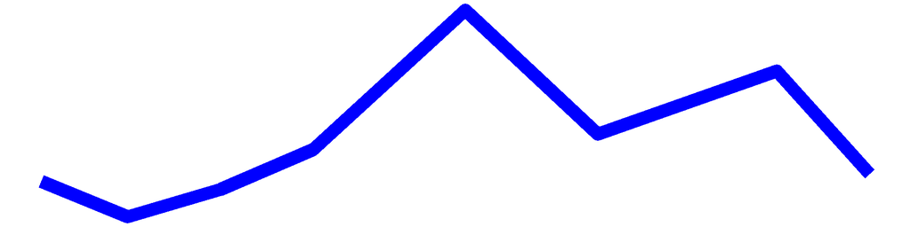

1.02871197

1.136

no.png

TDN (mg/L)

0.759

0.67

0.746

0.871

0.902

1.29

1.5

0.697

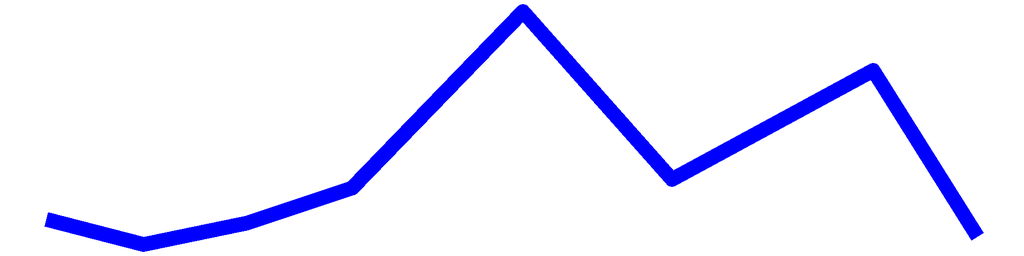

0.68412500

0.929

one_up_arrow.png

TN:TP

30

15

20

28

29

24

46

27

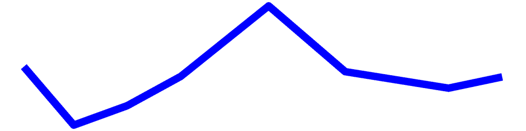

27

Surface NH3 (mg/L)

0.03

0.022

0.005

0.029

0.182

0.061

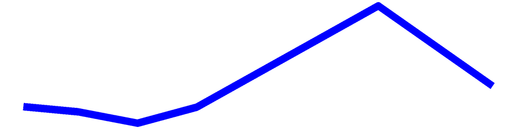

0.05926943

0.055

no.png

Chl.a (ug/L)

9.1

14.5

26

46.4

33.5

22.5

77.1

14.6

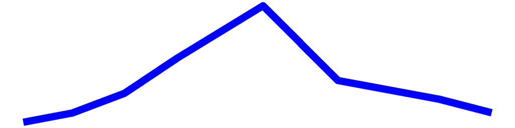

39.29267327

30.5

no.png

pH

8

7.8

7.4

7.8

7.2

9.3

7.1

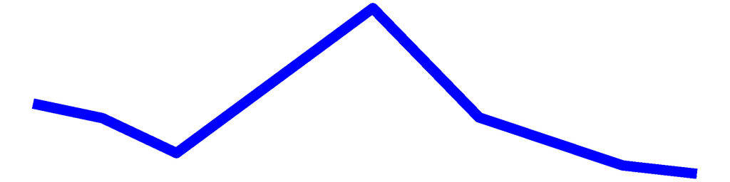

7.84485437

7.8

no.png

Cond (umho/cm)

345

375

380

388

381

371

410

336

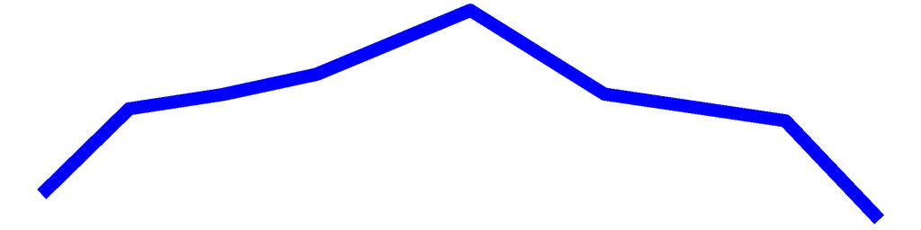

277.53980583

373

one_up_arrow.png

Surface Chloride (mg/L)

72

65.90000000

72

no.png

Upper Temp (degC)

25

22

23

29

25

21

26

18

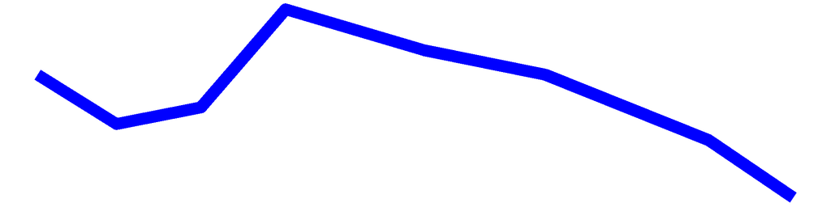

24.18279570

24

no.png

FP BG Chl.a (ug/L)

12.9

22.3

34.5

74.9

65.9

76.4

157.2

40.1

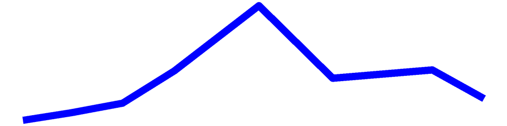

60.5

## Orange Lake – Sampling Season Results

### HABs Status

#### Open Water Algae

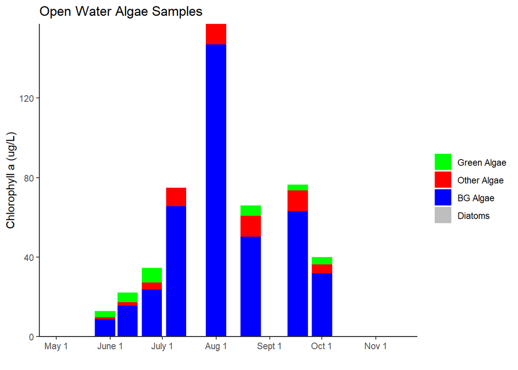

#### Shoreline Algae

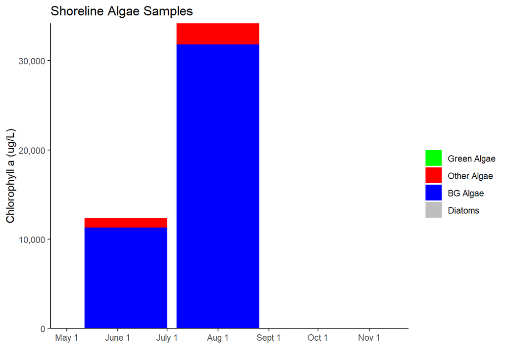

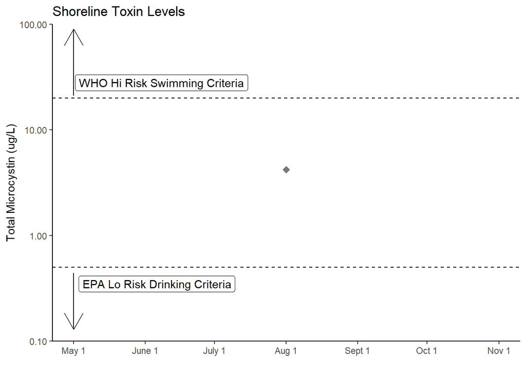

## Orange Lake Long-Term Trend Analysis

#### Clarity

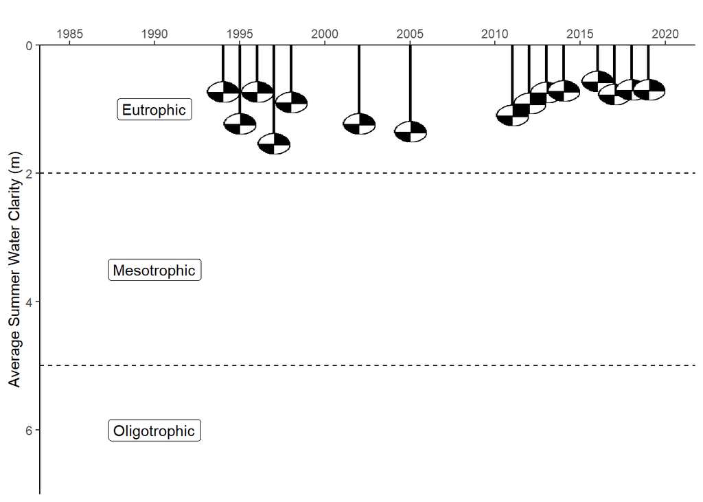

#### Chlorophyll *a*

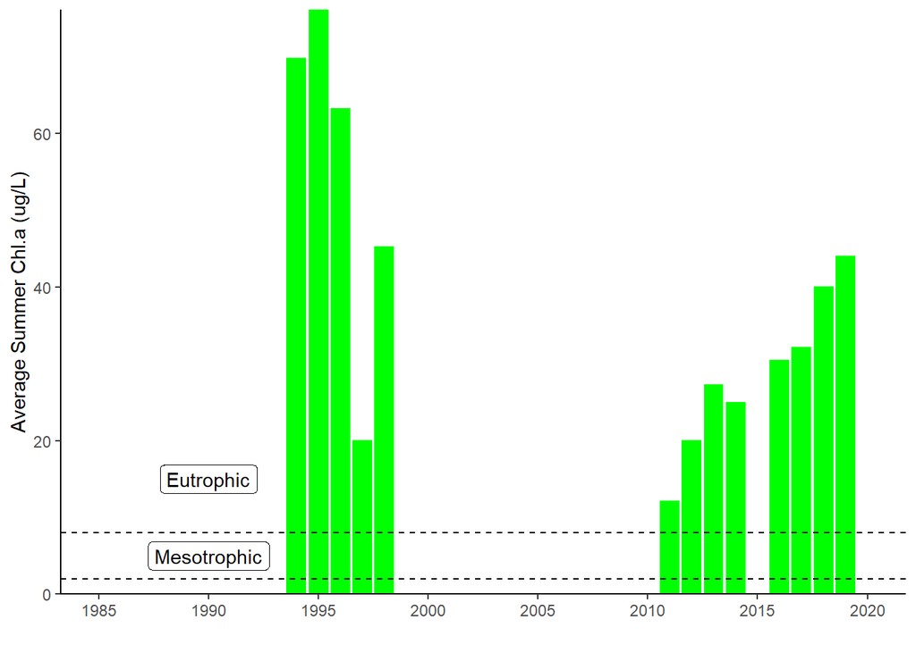

#### Surface and Deep Phosphorus

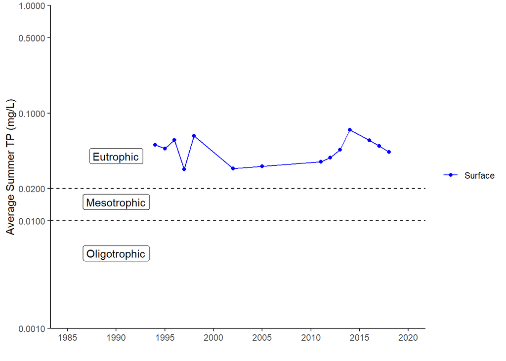

#### Nitrogen

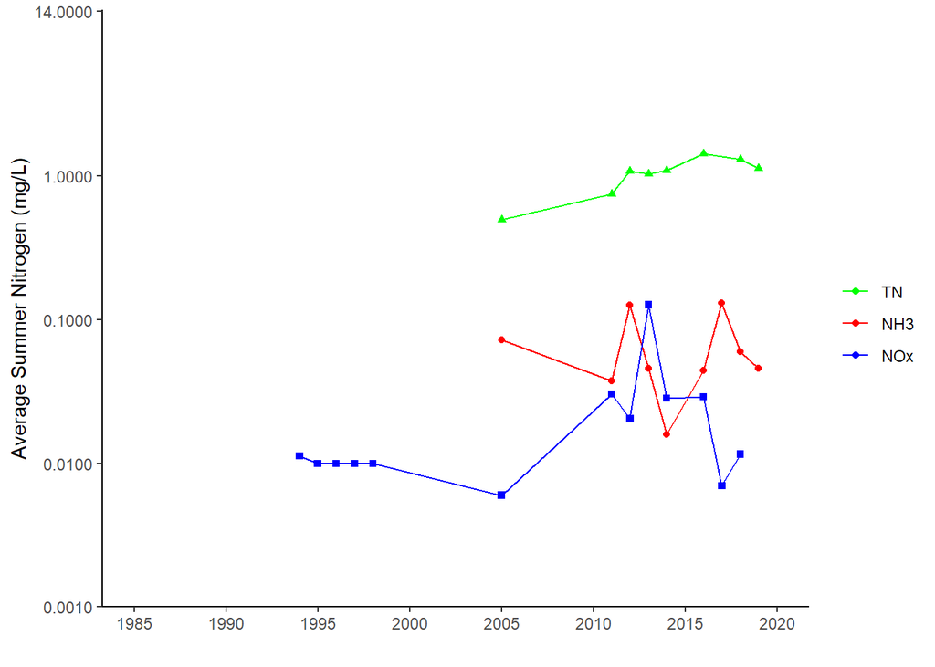

#### TN : TP

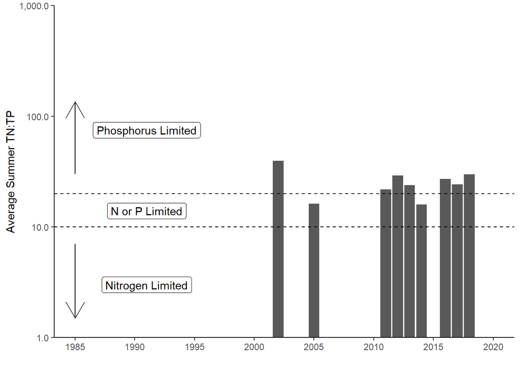

#### pH

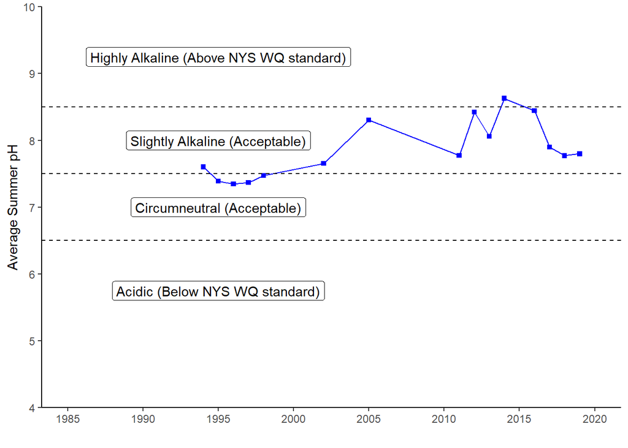

#### Specific Conductance

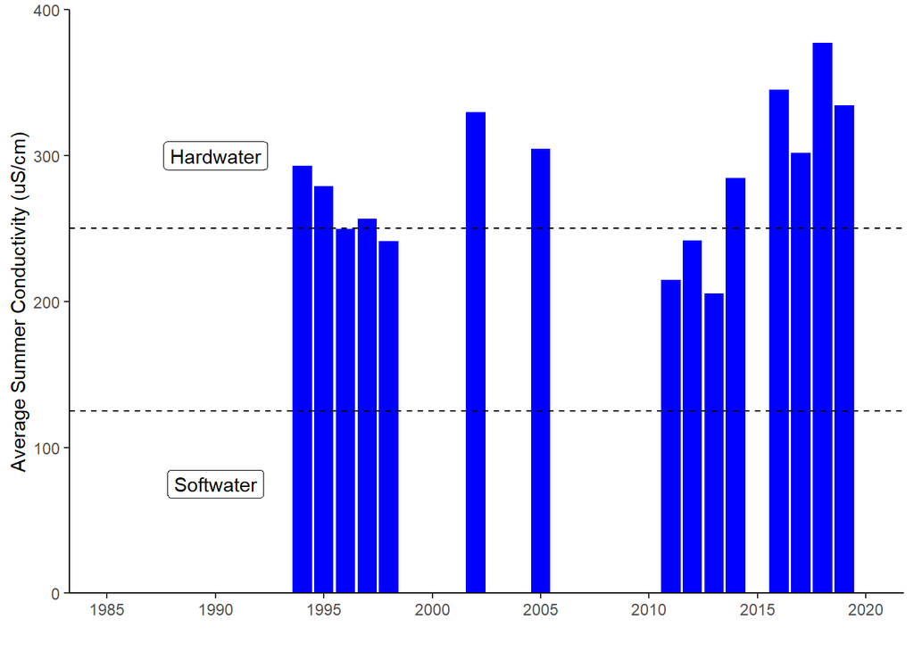

#### Calcium

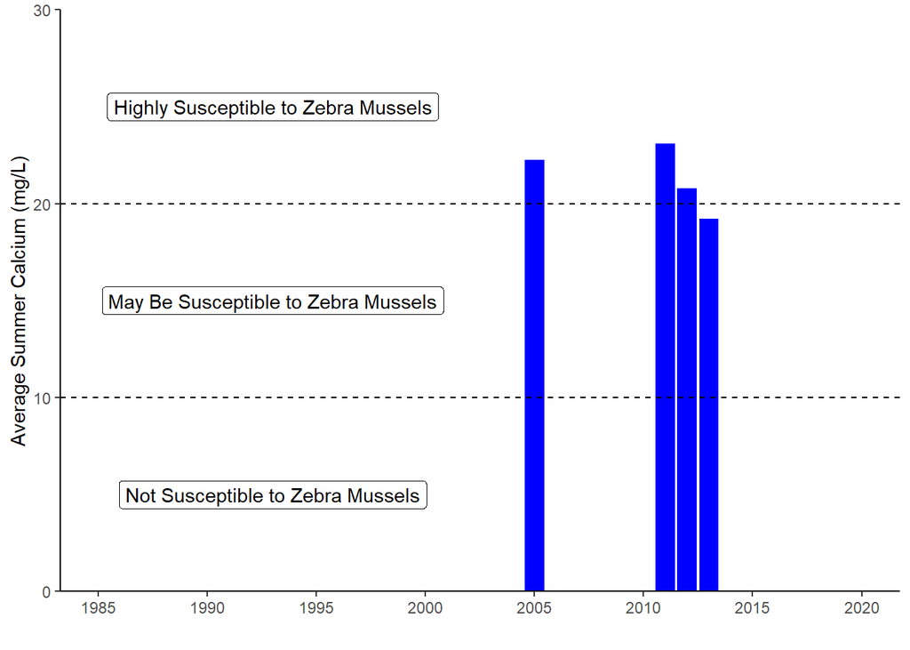

#### Chloride

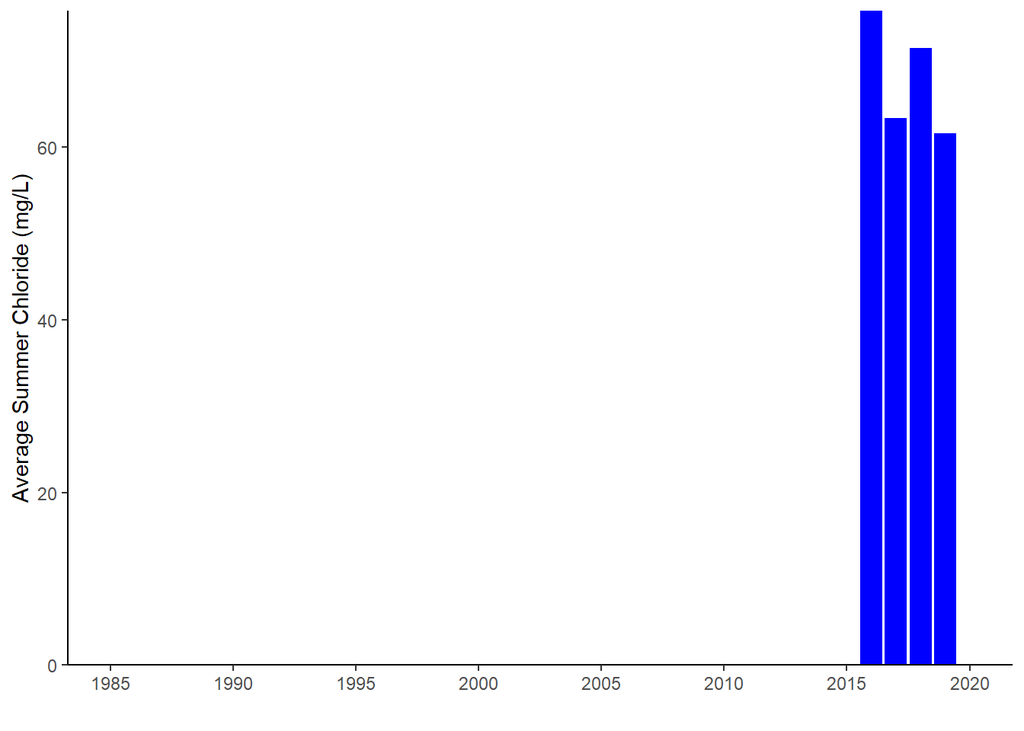

#### Color

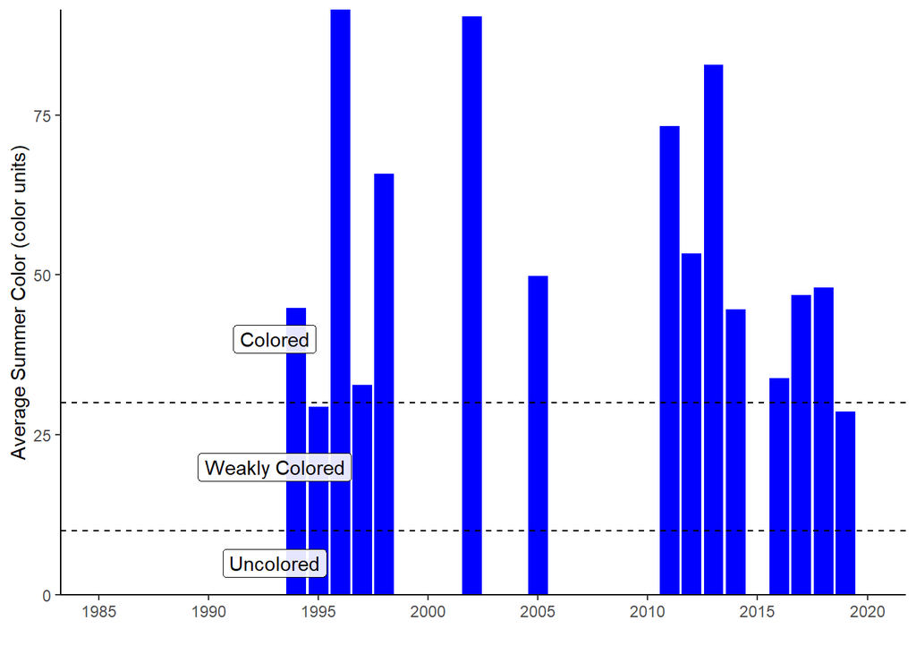

#### Surface and Deep Temperature

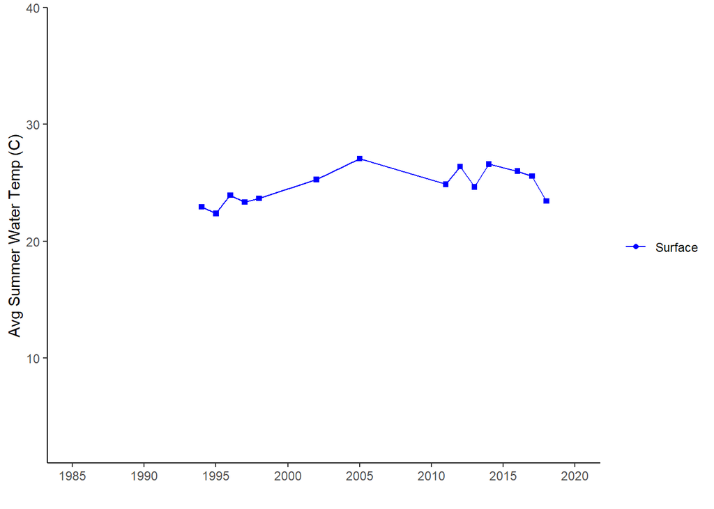

#### Lake Perception

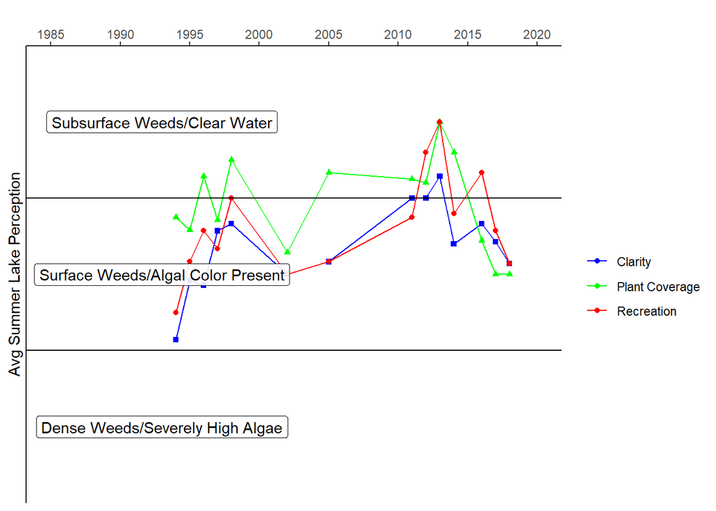

## Orange Lake - In-Season Analysis

#### In Season Water Clarity

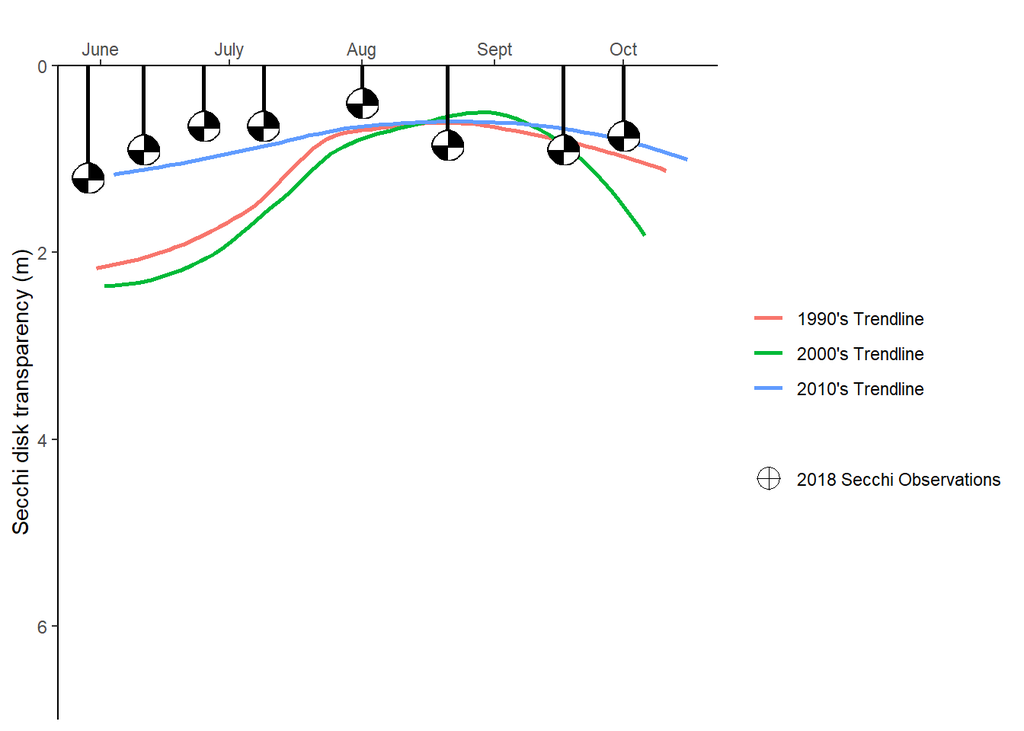

#### In Season Water Temperature

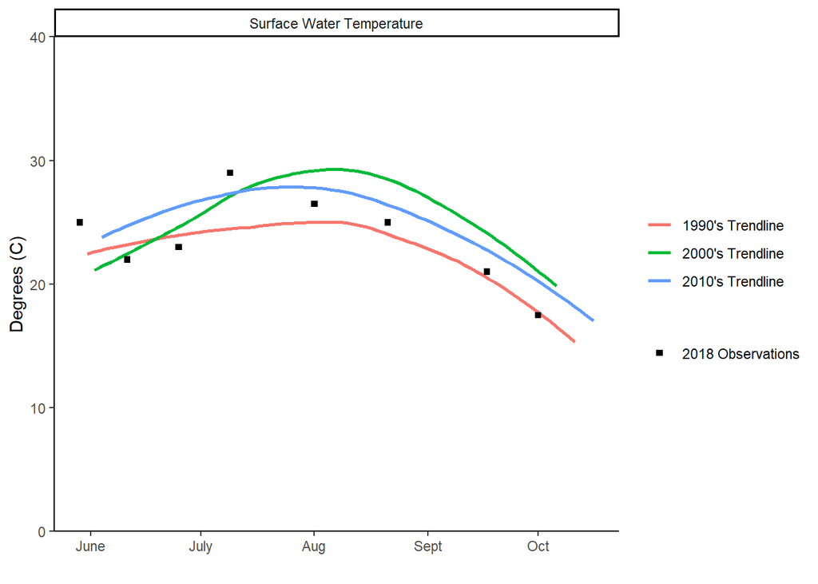